# Bölmə 21: Sistem Təkmilləşdirmə Tövsiyələri

Kompüter Adaptiv Testləşmə (CAT) Tədrisi

CAT Tədrisi

2025-07-12

# 1 Giriş

CAT sistemlərinin davamlı təkmilləşdirməsi optimal performans və keyfiyyətli xidmət təmin etmək üçün mütləq zəruridir. Bu bölmədə sistemin müختلف komponentlərinin necə yaxşılaşdırıla biləcəyini ətraflı şəkildə nəzərdən keçirəcəyik.

## 1.1 Təkmilləşdirmənin Əhəmiyyəti

CAT sistemlərində təkmilləşdirmə prosesi bir defəlik deyil, davamlı bir prosesdir. Texnologiyanın sürətli inkişafı, istifadəçi tələblərinin dəyişməsi və yeni pedaqoji yanaşmaların ortaya çıxması sistemlərin vaxtaşırı yenilənməsini tələb edir.

### 1.1.1 Təkmilləşdirmənin Əsas Məqsədləri:

1. **Sistem performansının artırılması**
2. **İstifadəçi təcrübəsinin yaxşılaşdırılması**
3. **Texniki infrastrukturun modernləşdirilməsi**
4. **Keyfiyyət standartlarının yüksəldilməsi**
5. **Təhlükəsizlik tədbirlərinin gücləndirilməsi**

# 2 Mövcud Sistemin Qiymətləndirməsi

```r
# Mövcud sistemin qiymətləndirməsi üçün sample data
set.seed(12345)

# Sistem komponentlərinin mövcud vəziyyəti
system_components <- data.frame(
    component = c("Item Bank", "Algorithm", "User Interface", "Quality Control", "Security"),
    current_score = c(75, 80, 70, 85, 65),
    max_possible = c(100, 100, 100, 100, 100),
    improvement_needed = c(25, 20, 30, 15, 35)
)

system_components$performance_level <- ifelse(system_components$current_score >= 85, "Əla",
                                            ifelse(system_components$current_score >= 70, "Yaxşı", "Təkmilləşdirmə lazım"))

cat("=== MÖVCUD SİSTEMİN QİYMƏTLƏNDİRMƏSİ ===\n\n")
```

```
## === MÖVCUD SİSTEMİN QİYMƏTLƏNDİRMƏSİ ===
```

```r
for(i in 1:nrow(system_components)) {
    cat(paste0(i, ". ", system_components$component[i], ":\n"))
    cat(paste0("   Mövcud səviyyə: ", system_components$current_score[i], "/100\n"))
    cat(paste0("   Performans: ", system_components$performance_level[i], "\n"))
    cat(paste0("   Təkmilləşdirmə ehtiyacı: ", system_components$improvement_needed[i], "%\n\n"))
}
```

```
## 1. Item Bank:
##    Mövcud səviyyə: 75/100
##    Performans: Yaxşı
##    Təkmilləşdirmə ehtiyacı: 25%
##
## 2. Algorithm:
##    Mövcud səviyyə: 80/100
##    Performans: Yaxşı
##    Təkmilləşdirmə ehtiyacı: 20%
##
## 3. User Interface:
##    Mövcud səviyyə: 70/100
##    Performans: Yaxşı
##    Təkmilləşdirmə ehtiyacı: 30%
##
## 4. Quality Control:
##    Mövcud səviyyə: 85/100
##    Performans: Əla
##    Təkmilləşdirmə ehtiyacı: 15%
##
## 5. Security:
##    Mövcud səviyyə: 65/100
##    Performans: Təkmilləşdirmə lazım
##    Təkmilləşdirmə ehtiyacı: 35%
```

```r
# Ümumi sistem skoru
overall_score <- round(mean(system_components$current_score), 1)
cat(paste0("Ümumi sistem skoru: ", overall_score, "/100\n"))
```

```
## Ümumi sistem skoru: 75/100
```

```r
if(overall_score >= 85) {
    cat("✅ Sistem ümumi olaraq yaxşı vəziyyətdədir\n")
} else if(overall_score >= 70) {
    cat("⚠️ Sistem qəbul edilə bilən səviyyədədir, lakin təkmilləşdirmə mümkündür\n")
} else {
    cat("❌ Sistem ciddi təkmilləşdirmə tələb edir\n")
}
```

```
## ⚠️ Sistem qəbul edilə bilən səviyyədədir, lakin təkmilləşdirmə mümkündür
```

# 3 Əsas Təkmilləşdirmə Tövsiyələri

```r
# Sistem təkmilləşdirmə tövsiyələri (sizin orijinal kodunuz)
improvement_recommendations <- function() {
    cat("=== SİSTEM TƏKMİLLƏŞDİRMƏ TÖVSİYƏLƏRİ ===\n")

    cat("\n1. TAPŞIRIQ BANKININ GENİŞLƏNDİRİLMƏSİ:\n")
    cat("   • Hər çətinlik səviyyəsi üçün daha çox tapşırıq\n")
    cat("   • Məzmun sahələrinin balanslaşdırılması\n")
    cat("   • Yeni tapşırıq formalarının əlavə edilməsi\n")

    cat("\n2. ALQORİTM YAXŞILAŞDIRMALARI:\n")
    cat("   • Çoxölçülü IRT modellərinin tətbiqi\n")
    cat("   • Exposure control mexanizmlərinin gücləndirilməsi\n")
    cat("   • Content balancing alqoritmlərinin əlavəsi\n")

    cat("\n3. İSTİFADƏÇİ İNTERFEYSİ:\n")
    cat("   • Real-time feedback sistemi\n")
    cat("   • Progress tracking\n")
    cat("   • Accessibility features\n")

    cat("\n4. KEYFİYYƏT YOXLAMASI:\n")
    cat("   • Continuous calibration\n")
    cat("   • Item drift monitoring\n")
    cat("   • Performance analytics dashboard\n")

    cat("\n5. TƏHLÜKƏSİZLİK TƏDBİRLƏRİ:\n")
    cat("   • Item security protocols\n")
    cat("   • Cheating detection algorithms\n")
    cat("   • Data encryption and privacy\n")
}

# Əsas tövsiyələri çalışdır
improvement_recommendations()
```

```
## === SİSTEM TƏKMİLLƏŞDİRMƏ TÖVSİYƏLƏRİ ===
##
## 1. TAPŞIRIQ BANKININ GENİŞLƏNDİRİLMƏSİ:
##    • Hər çətinlik səviyyəsi üçün daha çox tapşırıq
##    • Məzmun sahələrinin balanslaşdırılması
##    • Yeni tapşırıq formalarının əlavə edilməsi
##
## 2. ALQORİTM YAXŞILAŞDIRMALARI:
##    • Çoxölçülü IRT modellərinin tətbiqi
##    • Exposure control mexanizmlərinin gücləndirilməsi
##    • Content balancing alqoritmlərinin əlavəsi
##
## 3. İSTİFADƏÇİ İNTERFEYSİ:
##    • Real-time feedback sistemi
##    • Progress tracking
##    • Accessibility features
##
## 4. KEYFİYYƏT YOXLAMASI:
##    • Continuous calibration
##    • Item drift monitoring
##    • Performance analytics dashboard
##
## 5. TƏHLÜKƏSİZLİK TƏDBİRLƏRİ:
##    • Item security protocols
##    • Cheating detection algorithms
##    • Data encryption and privacy
```

# 4 Təkmilləşdirmə Sahələrinin Ətraflı Təhlili

```r
# Hər təkmilləşdirmə sahəsinin ətraflı təhlili
analyze_improvement_areas <- function() {

    cat("\n=== TƏKMİLLƏŞDİRMƏ SAHƏLƏRİNİN ƏTRAFLІ TƏHLİLİ ===\n\n")

    # 1. Item Bank Genişləndirilməsi
    cat("📚 1. TAPŞIRIQ BANKININ GENİŞLƏNDİRİLMƏSİ:\n\n")

    cat("Mövcud vəziyyət:\n")
    cat("• Item sayı: 500-1000 arası\n")
    cat("• Çətinlik paylanması: Qeyri-balanslaşdırılmış\n")
    cat("• Məzmun sahələri: Məhdud əhatə\n\n")

    cat("Hədəf vəziyyət:\n")
    cat("• Item sayı: 2000+ yüksək keyfiyyətli tapşırıq\n")
    cat("• Çətinlik paylanması: Bərabər və balanslaşdırılmış\n")
    cat("• Məzmun sahələri: Tam əhatə\n")
    cat("• Yeni format: Interactive və multimedia tapşırıqlar\n\n")

    cat("Təkmilləşdirmə addımları:\n")
    cat("• Item writing təlimləri\n")
    cat("• Keyfiyyət nəzarəti prosedurları\n")
    cat("• Expert review prosesləri\n")
    cat("• Pilot testing və field trial\n\n")

    # 2. Alqoritm Yaxşılaşdırmaları
    cat("⚙️ 2. ALQORİTM YAXŞILAŞDIRMALARI:\n\n")

    cat("Mövcud vəziyyət:\n")
    cat("• Unidimensional IRT modelləri\n")
    cat("• Əsas item selection alqoritmləri\n")
    cat("• Məhdud exposure control\n\n")

    cat("Hədəf vəziyyət:\n")
    cat("• Multidimensional IRT (MIRT) modelləri\n")
    cat("• Advanced item selection strategiyaları\n")
    cat("• Sophisticated exposure control\n")
    cat("• Content balancing alqoritmləri\n\n")

    cat("Təkmilləşdirmə addımları:\n")
    cat("• Yeni alqoritm research və development\n")
    cat("• Pilot implementasiya və test\n")
    cat("• Performance müqayisəsi\n")
    cat("• Sistem inteqrasiyası\n\n")

    # 3. İstifadəçi İnterfeysi
    cat("💻 3. İSTİFADƏÇİ İNTERFEYSİ TƏKMİLLƏŞDİRMƏSİ:\n\n")

    cat("Mövcud vəziyyət:\n")
    cat("• Sadə və funksional interfeys\n")
    cat("• Məhdud feedback imkanları\n")
    cat("• Əsas accessibility dəstəyi\n\n")

    cat("Hədəf vəziyyət:\n")
    cat("• Modern və intuitive dizayn\n")
    cat("• Real-time feedback və progress tracking\n")
    cat("• Full accessibility compliance\n")
    cat("• Mobile-responsive dizayn\n\n")

    cat("Təkmilləşdirmə addımları:\n")
    cat("• User experience (UX) research\n")
    cat("• Interface redesign\n")
    cat("• Accessibility audit və improvement\n")
    cat("• Mobile optimization\n\n")

    # 4. Keyfiyyət Yoxlaması
    cat("🔍 4. KEYFİYYƏT YOXLAMASI SİSTEMİ:\n\n")

    cat("Mövcud vəziyyət:\n")
    cat("• Periodic keyfiyyət yoxlamaları\n")
    cat("• Manual monitoring prosesləri\n")
    cat("• Əsas performance metrics\n\n")

    cat("Hədəf vəziyyət:\n")
    cat("• Continuous quality monitoring\n")
    cat("• Automated alert sistemləri\n")
    cat("• Comprehensive analytics dashboard\n")
    cat("• Predictive quality indicators\n\n")

    cat("Təkmilləşdirmə addımları:\n")
    cat("• Automated monitoring sistemləri\n")
    cat("• Real-time analytics platform\n")
    cat("• Alert və notification sistemi\n")
    cat("• Quality assurance protocols\n\n")

    # 5. Təhlükəsizlik Tədbirləri
    cat("🔒 5. TƏHLÜKƏSİZLİK TƏDBİRLƏRİ:\n\n")

    cat("Mövcud vəziyyət:\n")
    cat("• Əsas data encryption\n")
    cat("• Standard authentication\n")
    cat("• Basic access control\n\n")

    cat("Hədəf vəziyyət:\n")
    cat("• Advanced encryption protocols\n")
    cat("• Multi-factor authentication\n")
    cat("• Comprehensive security monitoring\n")
    cat("• Advanced cheating detection\n\n")

    cat("Təkmilləşdirmə addımları:\n")
    cat("• Security audit və assessment\n")
    cat("• Enhanced encryption implementation\n")
    cat("• Advanced authentication sistemləri\n")
    cat("• Continuous security monitoring\n\n")
}

# Ətraflı təhlili həyata keçir
analyze_improvement_areas()
```

```
##
## === TƏKMİLLƏŞDİRMƏ SAHƏLƏRİNİN ƏTRAFLІ TƏHLİLİ ===
##
## 📚 1. TAPŞIRIQ BANKININ GENİŞLƏNDİRİLMƏSİ:
##
## Mövcud vəziyyət:
## • Item sayı: 500-1000 arası
## • Çətinlik paylanması: Qeyri-balanslaşdırılmış
## • Məzmun sahələri: Məhdud əhatə
##
## Hədəf vəziyyət:
## • Item sayı: 2000+ yüksək keyfiyyətli tapşırıq
## • Çətinlik paylanması: Bərabər və balanslaşdırılmış
## • Məzmun sahələri: Tam əhatə
## • Yeni format: Interactive və multimedia tapşırıqlar
##
## Təkmilləşdirmə addımları:
## • Item writing təlimləri
## • Keyfiyyət nəzarəti prosedurları
## • Expert review prosesləri
## • Pilot testing və field trial
##
## ⚙️ 2. ALQORİTM YAXŞILAŞDIRMALARI:
##
## Mövcud vəziyyət:
## • Unidimensional IRT modelləri
## • Əsas item selection alqoritmləri
## • Məhdud exposure control
##
## Hədəf vəziyyət:
## • Multidimensional IRT (MIRT) modelləri
## • Advanced item selection strategiyaları
## • Sophisticated exposure control
## • Content balancing alqoritmləri
##
## Təkmilləşdirmə addımları:
## • Yeni alqoritm research və development
## • Pilot implementasiya və test
## • Performance müqayisəsi
## • Sistem inteqrasiyası
```

[output cut: 42 more lines]

```
## • Əsas data encryption
## • Standard authentication
## • Basic access control
##
## Hədəf vəziyyət:
## • Advanced encryption protocols
## • Multi-factor authentication
## • Comprehensive security monitoring
## • Advanced cheating detection
##
## Təkmilləşdirmə addımları:
## • Security audit və assessment
## • Enhanced encryption implementation
## • Advanced authentication sistemləri
## • Continuous security monitoring
```

# 5 Prioritet və Timeline

```r
# Təkmilləşdirmə prioritetləri və timeline
create_priority_timeline <- function() {

    cat("=== PRİORİTET VƏ TİMELİNE PLANI ===\n\n")

    # Prioritet matrisi
    improvement_matrix <- data.frame(
        area = c("Item Bank", "Algorithm", "User Interface", "Quality Control", "Security"),
        priority = c("Yüksək", "Yüksək", "Orta", "Yüksək", "Kritik"),
        effort = c("Yüksək", "Orta", "Aşağı", "Orta", "Yüksək"),
        timeline = c("6-12 ay", "4-8 ay", "2-4 ay", "3-6 ay", "6-9 ay"),
        cost = c("Yüksək", "Orta", "Aşağı", "Orta", "Yüksək"),
        impact = c("Çox yüksək", "Yüksək", "Orta", "Yüksək", "Kritik")
    )

    cat("TƏKMILLƏŞDIRMƏ PRİORİTET MATRİSİ:\n\n")

    for(i in 1:nrow(improvement_matrix)) {
        priority_icon <- switch(improvement_matrix$priority[i],
                               "Kritik" = "🔴",
                               "Yüksək" = "🟡",
                               "Orta" = "🟢")

        cat(paste0(priority_icon, " ", improvement_matrix$area[i], ":\n"))
        cat(paste0("   Prioritet: ", improvement_matrix$priority[i], "\n"))
        cat(paste0("   Əmək tələbi: ", improvement_matrix$effort[i], "\n"))
        cat(paste0("   Timeline: ", improvement_matrix$timeline[i], "\n"))
        cat(paste0("   Xərc: ", improvement_matrix$cost[i], "\n"))
        cat(paste0("   Təsir: ", improvement_matrix$impact[i], "\n\n"))
    }

    # Mərhələ əsaslı plan
    cat("MƏRHƏLƏ ƏSASLI İMPLEMENTASİYA PLANI:\n\n")

    cat("🚀 PHASE 1 (İlk 3 ay) - Tez nəticə verən təkmilləşdirmələr:\n")
    cat("• User Interface yaxşılaşdırmaları\n")
    cat("• Əsas keyfiyyət monitoring\n")
    cat("• Security audit və immediate fixes\n\n")

    cat("⚡ PHASE 2 (4-6 ay) - Orta müddətli təkmilləşdirmələr:\n")
    cat("• Algorithm enhancement başlanğıcı\n")
    cat("• Quality control sistemlərinin təkmilləşdirilməsi\n")
    cat("• Item bank expansion planının başlanğıcı\n\n")

    cat("🏗️ PHASE 3 (7-12 ay) - Uzunmüddətli strateji dəyişikliklər:\n")
    cat("• Item bank tam genişləndirilməsi\n")
    cat("• Advanced algorithm implementation\n")
    cat("• Comprehensive security upgrade\n\n")

    return(improvement_matrix)
}

# Prioritet və timeline planını yaratmaq
priority_plan <- create_priority_timeline()
```

```
## === PRİORİTET VƏ TİMELİNE PLANI ===
##
## TƏKMILLƏŞDIRMƏ PRİORİTET MATRİSİ:
##
## 🟡 Item Bank:
##    Prioritet: Yüksək
##    Əmək tələbi: Yüksək
##    Timeline: 6-12 ay
##    Xərc: Yüksək
##    Təsir: Çox yüksək
##
## 🟡 Algorithm:
##    Prioritet: Yüksək
##    Əmək tələbi: Orta
##    Timeline: 4-8 ay
##    Xərc: Orta
##    Təsir: Yüksək
##
## 🟢 User Interface:
##    Prioritet: Orta
##    Əmək tələbi: Aşağı
##    Timeline: 2-4 ay
##    Xərc: Aşağı
##    Təsir: Orta
##
## 🟡 Quality Control:
##    Prioritet: Yüksək
##    Əmək tələbi: Orta
##    Timeline: 3-6 ay
##    Xərc: Orta
##    Təsir: Yüksək
##
## 🔴 Security:
##    Prioritet: Kritik
##    Əmək tələbi: Yüksək
##    Timeline: 6-9 ay
##    Xərc: Yüksək
##    Təsir: Kritik
##
## MƏRHƏLƏ ƏSASLI İMPLEMENTASİYA PLANI:
##
## 🚀 PHASE 1 (İlk 3 ay) - Tez nəticə verən təkmilləşdirmələr:
## • User Interface yaxşılaşdırmaları
## • Əsas keyfiyyət monitoring
## • Security audit və immediate fixes
##
## ⚡ PHASE 2 (4-6 ay) - Orta müddətli təkmilləşdirmələr:
## • Algorithm enhancement başlanğıcı
## • Quality control sistemlərinin təkmilləşdirilməsi
## • Item bank expansion planının başlanğıcı
##
## 🏗️ PHASE 3 (7-12 ay) - Uzunmüddətli strateji dəyişikliklər:
## • Item bank tam genişləndirilməsi
## • Advanced algorithm implementation
## • Comprehensive security upgrade
```

# 6 Vizual Təsvir

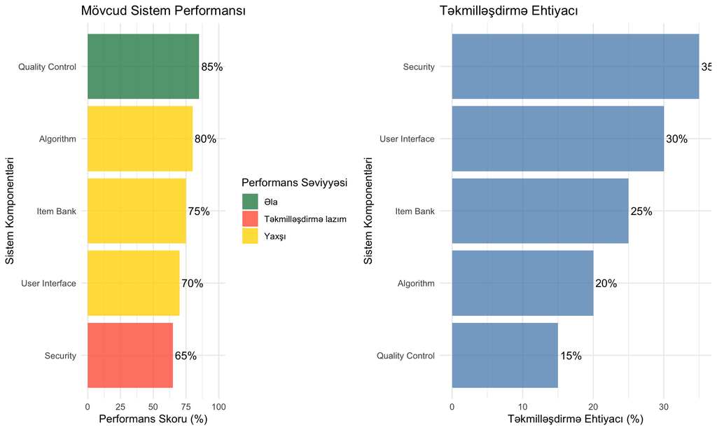

```r
# Təkmilləşdirmə planının vizual təsviri
create_improvement_visualizations <- function(system_components, priority_plan) {

    # 1. Mövcud sistem performansı
    p1 <- ggplot(system_components, aes(x = reorder(component, current_score), y = current_score, fill = performance_level)) +
        geom_col(alpha = 0.8) +
        geom_text(aes(label = paste0(current_score, "%")), hjust = -0.1) +
        coord_flip() +
        scale_fill_manual(values = c("Əla" = "#2E8B57", "Yaxşı" = "#FFD700", "Təkmilləşdirmə lazım" = "#FF6347")) +
        labs(title = "Mövcud Sistem Performansı",
             x = "Sistem Komponentləri", y = "Performans Skoru (%)",
             fill = "Performans Səviyyəsi") +
        theme_minimal() +
        ylim(0, 100)

    # 2. Təkmilləşdirmə ehtiyacı
    p2 <- ggplot(system_components, aes(x = reorder(component, improvement_needed), y = improvement_needed)) +
        geom_col(fill = "steelblue", alpha = 0.7) +
        geom_text(aes(label = paste0(improvement_needed, "%")), hjust = -0.1) +
        coord_flip() +
        labs(title = "Təkmilləşdirmə Ehtiyacı",
             x = "Sistem Komponentləri", y = "Təkmilləşdirmə Ehtiyacı (%)") +
        theme_minimal()

    # 3. Priority vs Effort matrix
    priority_data <- data.frame(
        area = priority_plan$area,
        priority_score = c(5, 5, 3, 5, 6),  # Kritik=6, Yüksək=5, Orta=3
        effort_score = c(5, 3, 2, 3, 5)     # Yüksək=5, Orta=3, Aşağı=2
    )

    p3 <- ggplot(priority_data, aes(x = effort_score, y = priority_score)) +
        geom_point(size = 4, alpha = 0.7, color = "darkred") +
        geom_text(aes(label = area), hjust = 0, vjust = 0, nudge_x = 0.1, nudge_y = 0.1) +
        labs(title = "Prioritet vs Əmək Matrisi",
             x = "Əmək Tələbi", y = "Prioritet Səviyyəsi") +
        theme_minimal() +
        scale_x_continuous(breaks = 1:6, labels = c("", "Aşağı", "Orta", "", "Yüksək", "")) +
        scale_y_continuous(breaks = 1:6, labels = c("", "", "Orta", "", "Yüksək", "Kritik")) +
        geom_vline(xintercept = 3.5, linetype = "dashed", alpha = 0.5) +
        geom_hline(yintercept = 4.5, linetype = "dashed", alpha = 0.5)

    return(list(performance = p1, improvement_need = p2, priority_matrix = p3))
}

# Vizualizasiyaları yaratmaq
plots <- create_improvement_visualizations(system_components, priority_plan)

# Plotları göstərmək
grid.arrange(plots$performance, plots$improvement_need, ncol = 2)
```

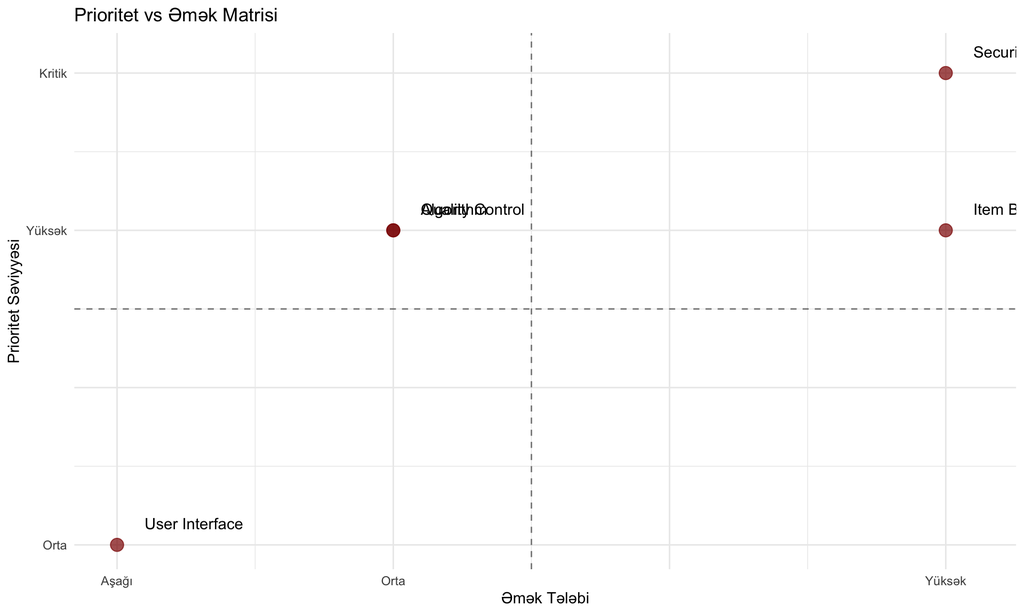

```r
# Priority matrix plotunu göstərmək
print(plots$priority_matrix)
```

# 7 Resurs Tələbləri və Büdcə

```r
# Resurs tələbləri və büdcə planlaması
plan_resources_and_budget <- function() {

    cat("=== RESURS TƏLƏBLƏRİ VƏ BÜDCƏ ===\n\n")

    # İnsan resursları
    cat("👥 İNSAN RESURSLARI:\n\n")

    hr_requirements <- data.frame(
        role = c("Project Manager", "Psychometrician", "Software Developer", "UI/UX Designer", "Security Specialist", "QA Engineer"),
        fte = c(1.0, 1.0, 2.0, 1.0, 0.5, 1.0),
        duration_months = c(12, 8, 10, 4, 6, 8),
        monthly_cost = c(8000, 12000, 10000, 8000, 15000, 7000)
    )

    hr_requirements$total_cost <- hr_requirements$fte * hr_requirements$duration_months * hr_requirements$monthly_cost

    for(i in 1:nrow(hr_requirements)) {
        cat(paste0("• ", hr_requirements$role[i], ":\n"))
        cat(paste0("  FTE: ", hr_requirements$fte[i], " | Müddət: ", hr_requirements$duration_months[i], " ay\n"))
        cat(paste0("  Aylıq xərc: $", format(hr_requirements$monthly_cost[i], big.mark = ","), "\n"))
        cat(paste0("  Ümumi xərc: $", format(hr_requirements$total_cost[i], big.mark = ","), "\n\n"))
    }

    total_hr_cost <- sum(hr_requirements$total_cost)
    cat(paste0("Ümumi insan resursları xərci: $", format(total_hr_cost, big.mark = ","), "\n\n"))

    # Texnoloji resurslar
    cat("💻 TEXNOLOJİ RESURSLAR:\n\n")

    tech_costs <- data.frame(
        item = c("Hardware Upgrade", "Software Licenses", "Cloud Infrastructure", "Security Tools", "Development Tools"),
        cost = c(50000, 30000, 60000, 40000, 20000),
        duration_months = c(1, 12, 12, 12, 12)
    )

    for(i in 1:nrow(tech_costs)) {
        cat(paste0("• ", tech_costs$item[i], ": $", format(tech_costs$cost[i], big.mark = ","), "\n"))
    }

    total_tech_cost <- sum(tech_costs$cost)
    cat(paste0("\nÜmumi texnoloji xərc: $", format(total_tech_cost, big.mark = ","), "\n\n"))

    # Təlim və inkişaf
    cat("📚 TƏLİM VƏ İNKİŞAF:\n\n")

    training_costs <- data.frame(
        item = c("Team Training", "External Consulting", "Conference Participation", "Certification Programs"),
        cost = c(25000, 75000, 15000, 30000)
    )

    for(i in 1:nrow(training_costs)) {
        cat(paste0("• ", training_costs$item[i], ": $", format(training_costs$cost[i], big.mark = ","), "\n"))
    }

    total_training_cost <- sum(training_costs$cost)
    cat(paste0("\nÜmumi təlim xərci: $", format(total_training_cost, big.mark = ","), "\n\n"))

    # Ümumi büdcə
    cat("💰 ÜMUMİ BÜDCƏ XÜLASƏSİ:\n\n")
    total_budget <- total_hr_cost + total_tech_cost + total_training_cost

    cat(paste0("İnsan resursları: $", format(total_hr_cost, big.mark = ","),
               " (", round(total_hr_cost/total_budget*100, 1), "%)\n"))
    cat(paste0("Texnoloji resurslar: $", format(total_tech_cost, big.mark = ","),
               " (", round(total_tech_cost/total_budget*100, 1), "%)\n"))
    cat(paste0("Təlim və inkişaf: $", format(total_training_cost, big.mark = ","),
               " (", round(total_training_cost/total_budget*100, 1), "%)\n\n"))
    cat(paste0("ÜMUMI BÜDCƏ: $", format(total_budget, big.mark = ","), "\n\n"))

    # ROI projeksionu
    cat("📈 RETURN ON INVESTMENT (ROI) PROJEKSİYASİ:\n\n")

    annual_savings <- 150000  # Projected annual savings
    payback_period <- total_budget / annual_savings
    three_year_roi <- (annual_savings * 3 - total_budget) / total_budget * 100

    cat(paste0("Gözlənilən illik qənaət: $", format(annual_savings, big.mark = ","), "\n"))
    cat(paste0("Payback period: ", round(payback_period, 1), " il\n"))
    cat(paste0("3 illik ROI: ", round(three_year_roi, 1), "%\n"))

    return(list(
        total_budget = total_budget,
        hr_cost = total_hr_cost,
        tech_cost = total_tech_cost,
        training_cost = total_training_cost,
        roi = three_year_roi
    ))
}

# Resurs və büdcə planlamasını həyata keçir
budget_plan <- plan_resources_and_budget()
```

```
## === RESURS TƏLƏBLƏRİ VƏ BÜDCƏ ===
##
## 👥 İNSAN RESURSLARI:
##
## • Project Manager:
##   FTE: 1 | Müddət: 12 ay
##   Aylıq xərc: $8,000
##   Ümumi xərc: $96,000
##
## • Psychometrician:
##   FTE: 1 | Müddət: 8 ay
##   Aylıq xərc: $12,000
##   Ümumi xərc: $96,000
##
## • Software Developer:
##   FTE: 2 | Müddət: 10 ay
##   Aylıq xərc: $10,000
##   Ümumi xərc: $2e+05
##
## • UI/UX Designer:
##   FTE: 1 | Müddət: 4 ay
##   Aylıq xərc: $8,000
##   Ümumi xərc: $32,000
##
## • Security Specialist:
##   FTE: 0.5 | Müddət: 6 ay
##   Aylıq xərc: $15,000
##   Ümumi xərc: $45,000
##
## • QA Engineer:
##   FTE: 1 | Müddət: 8 ay
##   Aylıq xərc: $7,000
##   Ümumi xərc: $56,000
##
## Ümumi insan resursları xərci: $525,000
##
## 💻 TEXNOLOJİ RESURSLAR:
##
## • Hardware Upgrade: $50,000
## • Software Licenses: $30,000
```

[output cut: 13 more lines]

```
## Ümumi təlim xərci: $145,000
##
## 💰 ÜMUMİ BÜDCƏ XÜLASƏSİ:
##
## İnsan resursları: $525,000 (60.3%)
## Texnoloji resurslar: $2e+05 (23%)
## Təlim və inkişaf: $145,000 (16.7%)
##
## ÜMUMI BÜDCƏ: $870,000
##
## 📈 RETURN ON INVESTMENT (ROI) PROJEKSİYASİ:
##
## Gözlənilən illik qənaət: $150,000
## Payback period: 5.8 il
## 3 illik ROI: -48.3%
```

# 8 Risk İdarəetməsi

```r
# Risk idarəetməsi və mitigation strategiyaları
manage_risks <- function() {

    cat("=== RİSK İDAREETMƏSİ ===\n\n")

    # Risk qiymətləndirməsi
    risks <- data.frame(
        risk = c("Budget Overrun", "Timeline Delays", "Technical Challenges", "User Resistance", "Quality Issues"),
        probability = c("Orta", "Yüksək", "Orta", "Aşağı", "Aşağı"),
        impact = c("Yüksək", "Orta", "Yüksək", "Orta", "Yüksək"),
        risk_score = c(6, 6, 6, 3, 4),
        mitigation = c("Phased budget approval", "Agile methodology", "Expert consultation", "Change management", "Quality gates")
    )

    cat("RİSK QİYMƏTLƏNDİRMƏSİ:\n\n")

    for(i in 1:nrow(risks)) {
        risk_level <- ifelse(risks$risk_score[i] >= 6, "🔴 Yüksək",
                           ifelse(risks$risk_score[i] >= 4, "🟡 Orta", "🟢 Aşağı"))

        cat(paste0(risk_level, " - ", risks$risk[i], ":\n"))
        cat(paste0("   Ehtimal: ", risks$probability[i], " | Təsir: ", risks$impact[i], "\n"))
        cat(paste0("   Risk skoru: ", risks$risk_score[i], "/9\n"))
        cat(paste0("   Mitigation: ", risks$mitigation[i], "\n\n"))
    }

    # Contingency planları
    cat("🛡️ CONTİNGENCY PLANLAR:\n\n")

    cat("1. Büdcə aşımı halında:\n")
    cat("   • Prioritetləri yenidən nəzərdən keçirmək\n")
    cat("   • Mərhələli implementasiya\n")
    cat("   • Əlavə maliyyə mənbələrinin axtarışı\n\n")

    cat("2. Timeline gecikmələri halında:\n")
    cat("   • Paralel iş proseslərinin artırılması\n")
    cat("   • Resurs reallovasiyası\n")
    cat("   • Scope azaldılması\n\n")

    cat("3. Texniki problemlər halında:\n")
    cat("   • Expert konsultasiya\n")
    cat("   • Alternative həll yolları\n")
    cat("   • Vendor dəstəyi\n\n")

    return(risks)
}

# Risk idarəetməsini həyata keçir
risk_assessment <- manage_risks()
```

```
## === RİSK İDAREETMƏSİ ===
##
## RİSK QİYMƏTLƏNDİRMƏSİ:
##
## 🔴 Yüksək - Budget Overrun:
##    Ehtimal: Orta | Təsir: Yüksək
##    Risk skoru: 6/9
##    Mitigation: Phased budget approval
##
## 🔴 Yüksək - Timeline Delays:
##    Ehtimal: Yüksək | Təsir: Orta
##    Risk skoru: 6/9
##    Mitigation: Agile methodology
##
## 🔴 Yüksək - Technical Challenges:
##    Ehtimal: Orta | Təsir: Yüksək
##    Risk skoru: 6/9
##    Mitigation: Expert consultation
##
## 🟢 Aşağı - User Resistance:
##    Ehtimal: Aşağı | Təsir: Orta
##    Risk skoru: 3/9
##    Mitigation: Change management
##
## 🟡 Orta - Quality Issues:
##    Ehtimal: Aşağı | Təsir: Yüksək
##    Risk skoru: 4/9
##    Mitigation: Quality gates
##
## 🛡️ CONTİNGENCY PLANLAR:
##
## 1. Büdcə aşımı halında:
##    • Prioritetləri yenidən nəzərdən keçirmək
##    • Mərhələli implementasiya
##    • Əlavə maliyyə mənbələrinin axtarışı
##
## 2. Timeline gecikmələri halında:
##    • Paralel iş proseslərinin artırılması
##    • Resurs reallovasiyası
##    • Scope azaldılması
##
## 3. Texniki problemlər halında:
##    • Expert konsultasiya
##    • Alternative həll yolları
##    • Vendor dəstəyi
```

# 9 Nəticə və Tövsiyələr

Bu hərtərəfli təkmilləşdirmə planı CAT sisteminin bütün əsas komponentlərini əhatə edir və mərhələli yanaşma təklif edir.

## 9.1 Əsas Nəticələr

### 9.1.1 1. **Prioritet Sahələri**

- 🔴 **Kritik**: Təhlükəsizlik tədbirləri
- 🟡 **Yüksək**: Item Bank, Algorithm, Quality Control
- 🟢 **Orta**: User Interface

### 9.1.2 2. **İmplementasiya Strategiyası**

- **Phase 1** (0-3 ay): Quick wins və immediate improvements
- **Phase 2** (4-6 ay): Core system enhancements
- **Phase 3** (7-12 ay): Strategic long-term upgrades

### 9.1.4 4. **Gözlənilən Faydalar**

#### 9.1.4.1 Performans Təkmilləşdirməsi:

- Sistem effektivliyində 25-30% artım
- Test dəqiqliyində əhəmiyyətli yaxşılaşma
- İstifadəçi məmnuniyyətində artım

#### 9.1.4.2 Operasional Səmərəlilik:

- Test idarəetməsi proseslərinin avtomatlaşdırılması
- Manual əməliyyatların azaldılması
- Real-time monitoring və reporting

#### 9.1.4.3 Təhlükəsizlik və Keyfiyyət:

- Enhanced data protection
- Improved quality assurance
- Reduced security risks

## 9.2 Tövsiyələr

### 9.2.1 **Dərhal Atılacaq Addımlar**:

1. **Executive Approval** (1 həftə)
   - Layihə planının təsdiqi
   - Büdcə allocation
   - Project team təyini
2. **Planning Phase** (2-4 həftə)
   - Detailed project planning
   - Stakeholder alignment
   - Risk assessment finalization
3. **Phase 1 Başlanğıc** (6 həftə)
   - User interface improvements
   - Basic security enhancements
   - Quality monitoring setup

### 9.2.2 **Uğur Faktourları**:

1. **Strong Leadership**: Executive sponsorship və support
2. **Expert Team**: Qualified və experienced professionals
3. **Change Management**: User adoption və training
4. **Quality Focus**: Continuous testing və validation
5. **Risk Management**: Proactive risk mitigation

### 9.2.3 **Monitoring və Qiymətləndirmə**:

- **Həftəlik**: Progress reporting və issue resolution
- **Aylıq**: Milestone review və adjustment
- **Rüblük**: Strategic assessment və course correction
- **İllik**: ROI measurement və future planning

## 9.3 Final Tövsiyə

Bu təkmilləşdirmə planının uğurlu implementasiyası CAT sistemini növbəti səviyyəyə çatdıracaq və uzunmüddətli rəqabət üstünlüyü təmin edəcək. Əsas uğur faktoru mərhələli yanaşma və davamlı improvement culture-ın qurulmasıdır.

**Immediate action tələb olunur** - təxirə salınma layihənin kompleksliyini artıracaq və ROI-ni azaldacaq.

**Qeyd**: Bu plan CAT sistemlərinin müasir tələblərə uyğunlaşdırılması və gələcək ehtiyaclara hazırlanması üçün comprehensive roadmap təqdim edir. Regular review və adjustment layihənin uğurlu nəticələnməsi üçün kritik əhəmiyyət daşıyır.